# Reproducible Research: Course Project 1

### Load and preprocess the data:

- Load and look at data:

```r
data <- read.csv("activity.csv")
summary(data)
```

```
##      steps                date          interval
##  Min.   :  0.00   2012-10-01:  288   Min.   :   0.0
##  1st Qu.:  0.00   2012-10-02:  288   1st Qu.: 588.8
##  Median :  0.00   2012-10-03:  288   Median :1177.5
##  Mean   : 37.38   2012-10-04:  288   Mean   :1177.5
##  3rd Qu.: 12.00   2012-10-05:  288   3rd Qu.:1766.2
##  Max.   :806.00   2012-10-06:  288   Max.   :2355.0
##  NA's   :2304     (Other)   :15840
```

```r
str(data)
```

```
## 'data.frame':    17568 obs. of  3 variables:
##  $ steps   : int  NA NA NA NA NA NA NA NA NA NA ...
##  $ date    : Factor w/ 61 levels "2012-10-01","2012-10-02",..: 1 1 1 1 1 1 1 1 1 1 ...
##  $ interval: int  0 5 10 15 20 25 30 35 40 45 ...
```

```r
head(data)
```

```
##   steps       date interval
## 1    NA 2012-10-01        0
## 2    NA 2012-10-01        5
## 3    NA 2012-10-01       10
## 4    NA 2012-10-01       15
## 5    NA 2012-10-01       20
## 6    NA 2012-10-01       25
```

- Transforming the data:

```r
data$day <- weekdays(as.Date(data$date))
data$DateTime <- as.POSIXct(data$date, format = "%Y-%m-%d")
cleanData<- subset(data, !is.na(data$steps))
head(cleanData)
```

```
##     steps       date interval     day   DateTime
## 289     0 2012-10-02        0 вторник 2012-10-02
## 290     0 2012-10-02        5 вторник 2012-10-02
## 291     0 2012-10-02       10 вторник 2012-10-02
## 292     0 2012-10-02       15 вторник 2012-10-02
## 293     0 2012-10-02       20 вторник 2012-10-02
## 294     0 2012-10-02       25 вторник 2012-10-02
```

### What is mean total number of steps taken per day?

```r
library(ggplot2)
library(plyr)
```

- Calculate the total number of steps taken per day:

```r
sumTable <- aggregate(data$steps ~ data$date, FUN = sum)
colnames(sumTable) <- c("Date", "Steps")
```

- Make a histogram of the total number of steps taken each day:

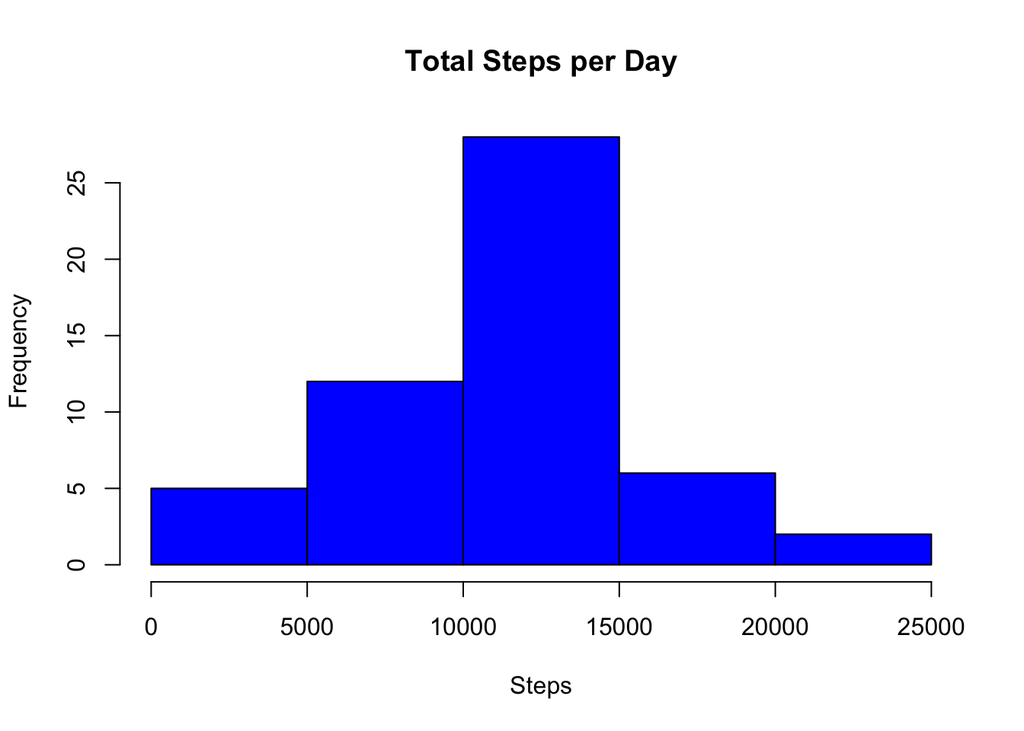

```r
hist(sumTable$Steps, breaks = 5, xlab = "Steps", main = "Total Steps per Day", col = "blue")
```

- Calculate and report the mean and median of the total number of steps taken per day:

```r
as.integer(mean(sumTable$Steps))
```

[1] 10766

```r
as.integer(median(sumTable$Steps))
```

[1] 10765

### What is the average daily activity pattern?

- Make a time series plot of the 5-minute interval and the average number of steps taken, averaged across all days (y-axis)

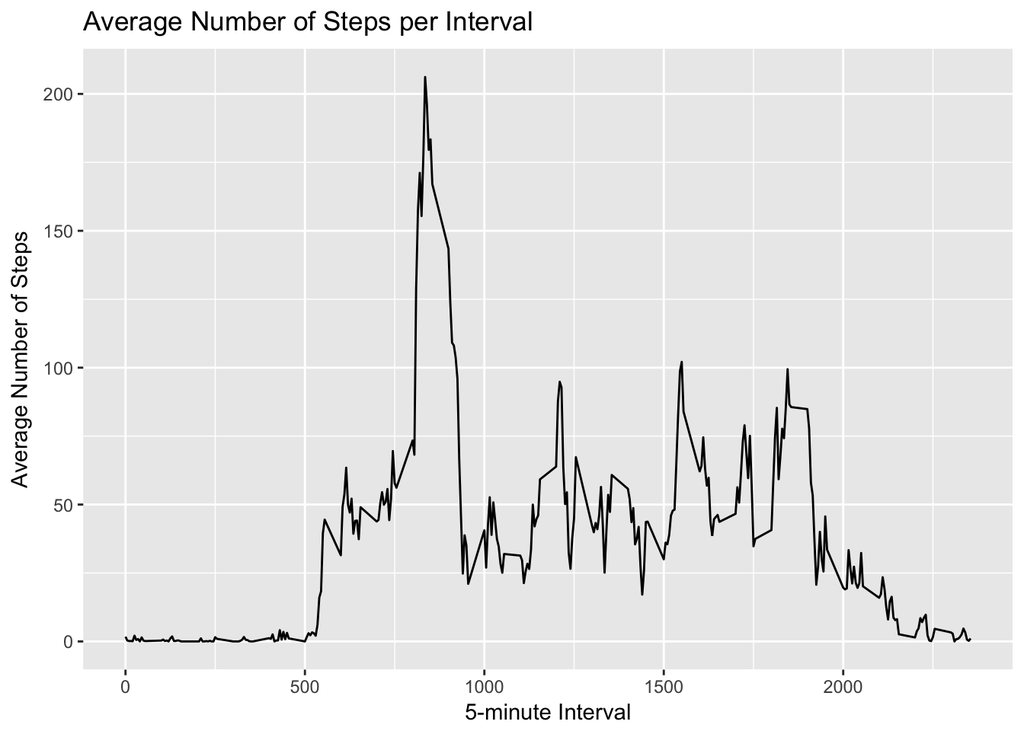

```r
intervalTable <- ddply(cleanData, .(interval), summarize, Avg = mean(steps))
g <- ggplot(intervalTable, aes(x = interval, y = Avg), xlab = "Interval", ylab = "Average Number of Steps")
g + geom_line() + xlab("5-minute Interval") + ylab("Average Number of Steps") + ggtitle("Average Number of Steps per Interval")
```

- Which 5-minute interval, on average across all the days in the dataset, contains the maximum number of steps?

```r
maxSteps <- max(intervalTable$Avg)
intervalTable[intervalTable$Avg == maxSteps, 1]
```

[1] 835

### Imputing missing values:

- Calculate and report the total number of missing values in the dataset:

```r
sum(is.na(data$steps))
```

[1] 2304

The original data set has 2304 rows with missing values.  
My strategy for filling in missing data will be to substitute NAs with the average 5-minute interval based on the day of the week.

- Devise a strategy for filling in all of the missing values in the dataset. The strategy does not need to be sophisticated. For example, you could use the mean/median for that day, or the mean for that 5-minute interval, etc.

```r
avgTable <- ddply(cleanData, .(interval, day), summarize, Avg = mean(steps))
dataNA <- data[is.na(data$steps), ]
filledData <- merge(dataNA, avgTable, by = c("interval", "day"))
```

- Create a new dataset that is equal to the original dataset but with the missing data filled in:

```r
newData <- filledData[ , c(6,4,1,2,5)]
colnames(newData) <- c("steps", "date", "interval", "day", "DateTime")
mergedData <- rbind(cleanData, newData)
```

- Make a histogram of the total number of steps taken each day and Calculate and report the mean and median total number of steps taken per day. Do these values differ from the estimates from the first part of the assignment? What is the impact of imputing missing data on the estimates of the total daily number of steps?

```r
sumTable2 <- aggregate(mergedData$steps ~ mergedData$date, FUN=sum)
colnames(sumTable2)<- c("Date", "Steps")
as.integer(mean(sumTable2$Steps))
```

[1] 10821

```r
as.integer(median(sumTable2$Steps))
```

[1] 11015

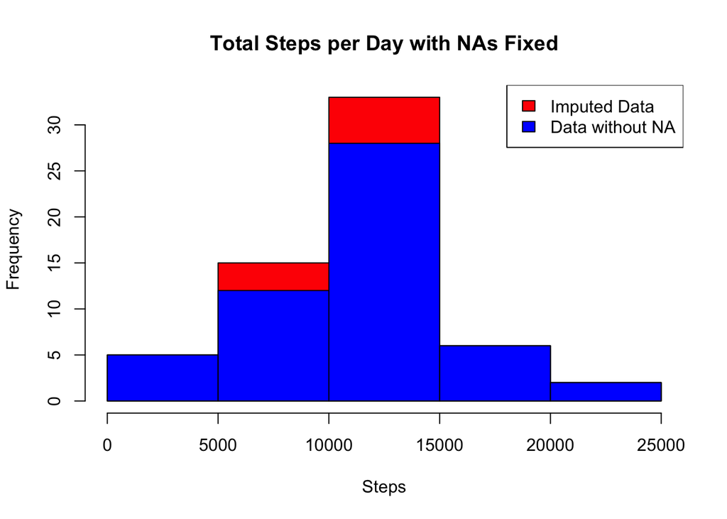

```r
hist(sumTable2$Steps, breaks = 5, xlab = "Steps", main = "Total Steps per Day with NAs Fixed", col = "red")
hist(sumTable$Steps, breaks = 5, xlab="Steps", main = "Total Steps per Day with NAs Fixed", col = "blue", add = T)
legend("topright", c("Imputed Data", "Data without NA"), fill = c("red", "blue"))
```

The new mean of the imputed data is 10821 steps compared to the old mean of 10766 steps, so the difference is 55 steps on average per day.

The new median of the imputed data is 11015 steps compared to the old median of 10765 steps, so the difference is 250 steps for the median.

```r
mergedData$date <- as.Date(strptime(mergedData$date, format="%Y-%m-%d"))
mergedData$day <- weekdays(mergedData$date)
for (i in 1:nrow(mergedData)) {
    if (mergedData[i,]$day %in% c("Saturday","Sunday")) {
        mergedData[i,]$day<-"weekend"
    }
    else{
        mergedData[i,]$day<-"weekday"
    }
}
stepsByDay <- aggregate(mergedData$steps ~ mergedData$interval + mergedData$day, mergedData, mean)
```

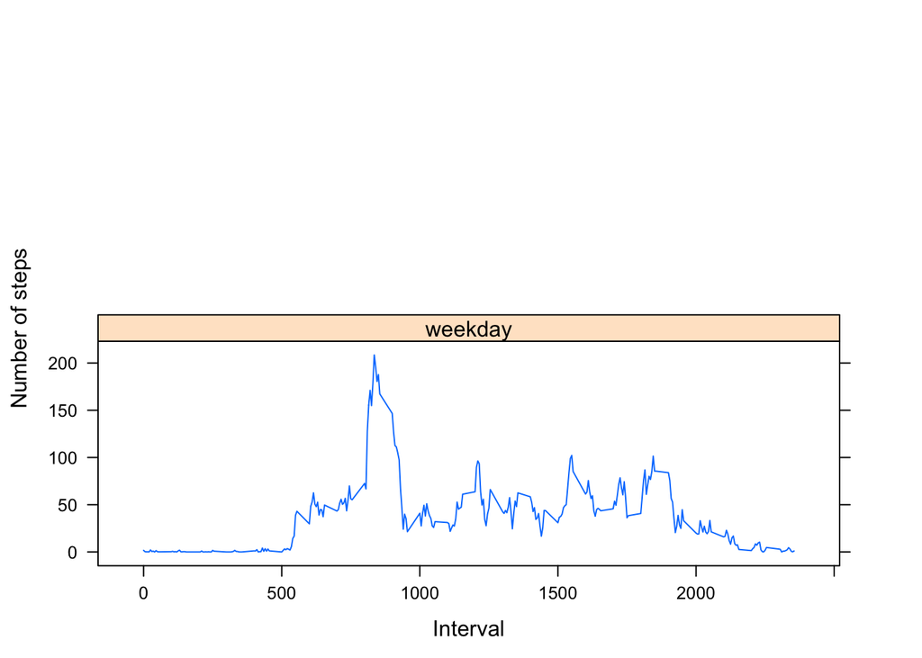

```r
names(stepsByDay) <- c("interval", "day", "steps")
library(lattice)
xyplot(steps ~ interval | day, stepsByDay, type = "l", layout = c(1, 2),
    xlab = "Interval", ylab = "Number of steps")
```